# Actividad 3 Estadística y R

Equipo 1 UNIR: Maria Luisa Alonso Núñez, Sara Cerezuela Martínez, Gracia Gimeno Almiñana, Guillermo Mora Collado y Gorka Suárez González

2025-01-21

El objetivo de esta actividad es aplicar los conceptos aprendidos durante la materia (visualización gráfica, análisis descriptivos, contrastes de hipótesis, PCA,…). Utilizaremos un *dataset* que contienen información de la expresión de 46 genes en 65 pacientes, cada uno con distintos tipos de tratamiento y características tumorales.

## 0. Carga de liberías y preparación de los datos

Carga de las librerías necesarias para el desarrollo de la actividad.

Seleccionamos el directorio y cargamos la base de datos “Dataset expresión genes” con la que trabajaremos durante la actividad. Con la función **any(is.na(df))** comprobamos que no haya missings en los datos proporcionados.

```r
path <- "~/Desktop/UNIR/Estadística y R para Ciencias de la Salud/Actividades /Actividad 3"
setwd(path)
df <- read.csv("Dataset expresion genes.csv", sep=',')
View(df)
any(is.na(df))
```

```
## [1] FALSE
```

Creamos un data frame que contenga los datos de los genes para trabajar con ellos más adelante.

```r
genes <- grep("AQ_", colnames(df), value = TRUE)
genes_df <- df[, genes]
any(is.na(genes_df))
```

```
## [1] FALSE
```

## 1. Comprobar la normalidad de los genes y realizar una interpretación de los resultados obtenidos

### 1.1. Comprobamos la normalidad de los genes.

```r
nombre_genes<-colnames(genes_df)
resultados<-data.frame(gen=nombre_genes,p_valor=numeric((length(genes_df))))
```

Gen sera igual a los elementos contenidos en el vector nombre_genes valor_p . De momento la creo vacia pero establezco su longitud para que sea la misma que elementos tiene el vector nomre_genes.

A continuación, uso de notacion cientifica con 3 cifras significativas debido a los valores tan bajos obtenidos En caso de hacer “scientific = F”, aun cogiendo 5 cifras seguiria siendo 0 que visualmente queda peor

Principios del Shapiro Test: H0 si p_value > = 0.05 -> Asumo normalidad H1 si p_value < 0.05 -> Asumo que no hay normalidad en mis datos

```r
for (i in 1:length(nombre_genes)) {
  normalidad <- shapiro.test(df[[nombre_genes[i]]])
  resultados[i, "p_valor"] <- signif(normalidad$p.value,3)
}


resultados$interpretacion <- numeric(length(genes)) # Creo la columna vacia para la interpretacion
resultados$p_valor<- as.numeric(resultados$p_valor)

# Añadir al dataframe una columna donde se interprete la prueba de normalidad y otra donde se especifique el tipo de test usado


for (i in 1:nrow(resultados)) {
  resultados[i, "interpretacion"] <- ifelse(resultados$p_valor[i] < 0.05, "no presenta normalidad", "normalidad")
}


resultados$test<-numeric(length(genes)) # Creo la columna vacia para el tipo de test usado

for (i in 1:nrow(resultados)){
  resultados[i, "test"]<-  (" Shapiro Test")
}
```

### 1.2 Creacion de la Tabla 1

(Al ejecutar el siguiente chunk aparecen 2 objetos *shiny.tag*, el importante es el segundo que es el que mas completo esta)

```r
resultados %>%
  gt()
```

| gen | p_valor | interpretacion | test |
| --- | --- | --- | --- |
| AQ_ADIPOQ | 5.92e-18 | no presenta normalidad | Shapiro Test |
| AQ_ALOX5 | 9.32e-07 | no presenta normalidad | Shapiro Test |
| AQ_ARG1 | 3.42e-10 | no presenta normalidad | Shapiro Test |
| AQ_BMP2 | 6.22e-09 | no presenta normalidad | Shapiro Test |
| AQ_CCL2 | 1.54e-12 | no presenta normalidad | Shapiro Test |
| AQ_CCL5 | 1.32e-07 | no presenta normalidad | Shapiro Test |
| AQ_CCR5 | 8.19e-09 | no presenta normalidad | Shapiro Test |
| AQ_CD274 | 6.95e-08 | no presenta normalidad | Shapiro Test |
| AQ_CD36 | 1.38e-04 | no presenta normalidad | Shapiro Test |
| AQ_CHKA | 1.29e-06 | no presenta normalidad | Shapiro Test |
| AQ_CPT1A | 1.19e-06 | no presenta normalidad | Shapiro Test |
| AQ_CSF2 | 5.93e-09 | no presenta normalidad | Shapiro Test |
| AQ_CXCR1 | 9.82e-09 | no presenta normalidad | Shapiro Test |
| AQ_FASN | 1.82e-06 | no presenta normalidad | Shapiro Test |
| AQ_FOXO3 | 2.60e-06 | no presenta normalidad | Shapiro Test |
| AQ_FOXP3 | 2.01e-11 | no presenta normalidad | Shapiro Test |
| AQ_G6PD | 4.23e-06 | no presenta normalidad | Shapiro Test |
| AQ_GPD2 | 8.77e-08 | no presenta normalidad | Shapiro Test |
| AQ_GPX1 | 2.07e-04 | no presenta normalidad | Shapiro Test |
| AQ_IFNG | 8.04e-09 | no presenta normalidad | Shapiro Test |
| AQ_IL10 | 1.15e-13 | no presenta normalidad | Shapiro Test |
| AQ_IL1B | 1.87e-09 | no presenta normalidad | Shapiro Test |
| AQ_IL6 | 5.05e-12 | no presenta normalidad | Shapiro Test |
| AQ_IRS1 | 2.09e-06 | no presenta normalidad | Shapiro Test |
| AQ_JAK1 | 3.27e-06 | no presenta normalidad | Shapiro Test |
| AQ_JAK3 | 5.08e-11 | no presenta normalidad | Shapiro Test |
| AQ_LDHA | 9.18e-05 | no presenta normalidad | Shapiro Test |
| AQ_LIF | 1.21e-10 | no presenta normalidad | Shapiro Test |
| AQ_MAPK1 | 3.23e-05 | no presenta normalidad | Shapiro Test |
| AQ_NFE2L2 | 1.95e-06 | no presenta normalidad | Shapiro Test |
| AQ_NFKB1 | 1.46e-04 | no presenta normalidad | Shapiro Test |
| AQ_NLRP3 | 1.45e-06 | no presenta normalidad | Shapiro Test |
| AQ_NOS2 | 5.91e-12 | no presenta normalidad | Shapiro Test |
| AQ_NOX5 | 5.92e-18 | no presenta normalidad | Shapiro Test |
| AQ_PDCD1 | 6.54e-12 | no presenta normalidad | Shapiro Test |
| AQ_PPARG | 2.96e-11 | no presenta normalidad | Shapiro Test |
| AQ_PTAFR | 9.06e-06 | no presenta normalidad | Shapiro Test |
| AQ_PTGS2 | 9.30e-08 | no presenta normalidad | Shapiro Test |
| AQ_SLC2A4 | 4.43e-11 | no presenta normalidad | Shapiro Test |
| AQ_SOD1 | 3.88e-07 | no presenta normalidad | Shapiro Test |
| AQ_SREBF1 | 5.25e-05 | no presenta normalidad | Shapiro Test |
| AQ_STAT3 | 1.34e-09 | no presenta normalidad | Shapiro Test |
| AQ_TGFB1 | 2.22e-07 | no presenta normalidad | Shapiro Test |
| AQ_TLR3 | 5.59e-11 | no presenta normalidad | Shapiro Test |
| AQ_TLR4 | 4.08e-06 | no presenta normalidad | Shapiro Test |
| AQ_TNF | 8.87e-08 | no presenta normalidad | Shapiro Test |

```r
# Aplicar estilos al cuerpo de la tabla

tabla1 <- resultados %>%
  gt() %>%
  tab_style(
    style = cell_fill(color = "lightblue"),
    locations = cells_body(
      columns = "gen"
    )
  ) %>%
  tab_style(
    style = cell_text(color = "red"),
    locations = cells_body(
      columns = "interpretacion",
      rows = interpretacion == "no presenta normalidad"
    )
  ) %>%
  tab_style(
    style = cell_text(weight = "bold"),
    locations = cells_column_labels()
  ) %>%
  tab_header(title = md("**Tabla 1**"), subtitle = md("**Comprobar normalidad de los genes**") )

tabla1
```

**Tabla 1**

**Comprobar normalidad de los genes**

| gen | p_valor | interpretacion | test |
| --- | --- | --- | --- |
| AQ_ADIPOQ | 5.92e-18 | no presenta normalidad | Shapiro Test |
| AQ_ALOX5 | 9.32e-07 | no presenta normalidad | Shapiro Test |
| AQ_ARG1 | 3.42e-10 | no presenta normalidad | Shapiro Test |
| AQ_BMP2 | 6.22e-09 | no presenta normalidad | Shapiro Test |
| AQ_CCL2 | 1.54e-12 | no presenta normalidad | Shapiro Test |
| AQ_CCL5 | 1.32e-07 | no presenta normalidad | Shapiro Test |
| AQ_CCR5 | 8.19e-09 | no presenta normalidad | Shapiro Test |
| AQ_CD274 | 6.95e-08 | no presenta normalidad | Shapiro Test |
| AQ_CD36 | 1.38e-04 | no presenta normalidad | Shapiro Test |
| AQ_CHKA | 1.29e-06 | no presenta normalidad | Shapiro Test |
| AQ_CPT1A | 1.19e-06 | no presenta normalidad | Shapiro Test |
| AQ_CSF2 | 5.93e-09 | no presenta normalidad | Shapiro Test |
| AQ_CXCR1 | 9.82e-09 | no presenta normalidad | Shapiro Test |
| AQ_FASN | 1.82e-06 | no presenta normalidad | Shapiro Test |
| AQ_FOXO3 | 2.60e-06 | no presenta normalidad | Shapiro Test |
| AQ_FOXP3 | 2.01e-11 | no presenta normalidad | Shapiro Test |
| AQ_G6PD | 4.23e-06 | no presenta normalidad | Shapiro Test |
| AQ_GPD2 | 8.77e-08 | no presenta normalidad | Shapiro Test |
| AQ_GPX1 | 2.07e-04 | no presenta normalidad | Shapiro Test |
| AQ_IFNG | 8.04e-09 | no presenta normalidad | Shapiro Test |
| AQ_IL10 | 1.15e-13 | no presenta normalidad | Shapiro Test |
| AQ_IL1B | 1.87e-09 | no presenta normalidad | Shapiro Test |
| AQ_IL6 | 5.05e-12 | no presenta normalidad | Shapiro Test |
| AQ_IRS1 | 2.09e-06 | no presenta normalidad | Shapiro Test |
| AQ_JAK1 | 3.27e-06 | no presenta normalidad | Shapiro Test |
| AQ_JAK3 | 5.08e-11 | no presenta normalidad | Shapiro Test |
| AQ_LDHA | 9.18e-05 | no presenta normalidad | Shapiro Test |
| AQ_LIF | 1.21e-10 | no presenta normalidad | Shapiro Test |
| AQ_MAPK1 | 3.23e-05 | no presenta normalidad | Shapiro Test |
| AQ_NFE2L2 | 1.95e-06 | no presenta normalidad | Shapiro Test |
| AQ_NFKB1 | 1.46e-04 | no presenta normalidad | Shapiro Test |
| AQ_NLRP3 | 1.45e-06 | no presenta normalidad | Shapiro Test |
| AQ_NOS2 | 5.91e-12 | no presenta normalidad | Shapiro Test |
| AQ_NOX5 | 5.92e-18 | no presenta normalidad | Shapiro Test |
| AQ_PDCD1 | 6.54e-12 | no presenta normalidad | Shapiro Test |
| AQ_PPARG | 2.96e-11 | no presenta normalidad | Shapiro Test |
| AQ_PTAFR | 9.06e-06 | no presenta normalidad | Shapiro Test |
| AQ_PTGS2 | 9.30e-08 | no presenta normalidad | Shapiro Test |
| AQ_SLC2A4 | 4.43e-11 | no presenta normalidad | Shapiro Test |
| AQ_SOD1 | 3.88e-07 | no presenta normalidad | Shapiro Test |
| AQ_SREBF1 | 5.25e-05 | no presenta normalidad | Shapiro Test |
| AQ_STAT3 | 1.34e-09 | no presenta normalidad | Shapiro Test |
| AQ_TGFB1 | 2.22e-07 | no presenta normalidad | Shapiro Test |
| AQ_TLR3 | 5.59e-11 | no presenta normalidad | Shapiro Test |
| AQ_TLR4 | 4.08e-06 | no presenta normalidad | Shapiro Test |
| AQ_TNF | 8.87e-08 | no presenta normalidad | Shapiro Test |

## 2. PCA

### 2.1. Aplicación del PCA y elecciones de componentes principales

#### 2.1.1 Implementacion del modelo

```r
# 1. Creacion del modelo
pca_genes <- prcomp(genes_df, scale = TRUE)

names(pca_genes)
```

```
## [1] "sdev"     "rotation" "center"   "scale"    "x"
```

```r
head(pca_genes$rotation)[, 1:5]
```

```
##                   PC1         PC2         PC3          PC4         PC5
## AQ_ADIPOQ  0.03559292  0.05963402 -0.20119804  0.615234795 -0.12541590
## AQ_ALOX5  -0.16255105 -0.08922514 -0.01900273  0.013588585 -0.15843408
## AQ_ARG1   -0.06161307 -0.37261844  0.08743307 -0.004401589  0.04093470
## AQ_BMP2   -0.12301246 -0.09797195  0.02132068  0.052216821  0.30415167
## AQ_CCL2   -0.10851915  0.33932607 -0.14776708 -0.144249350 -0.08446118
## AQ_CCL5   -0.18409559  0.02951846  0.08351016  0.059369744  0.04839966
```

```r
dim(pca_genes$rotation)
```

```
## [1] 46 46
```

```r
head(pca_genes$x)[,1:5]
```

```
##            PC1         PC2         PC3        PC4        PC5
## [1,]  5.089935 -0.01809364 -0.03515134 -0.3669012 -0.0173304
## [2,]  5.487931  0.29917297 -0.31489425 -0.3375097  0.1043842
## [3,] -2.241975 -2.13642061  0.21785210  0.3246114  1.1361240
## [4,]  2.705509 -0.14204027  0.93350443 -0.4538535 -0.8509414
## [5,]  4.377338  0.21156271 -0.05134963 -0.2050323  0.2172005
## [6,]  3.674506 -1.00059794  0.18600847 -0.2999108  0.2132024
```

```r
# Desviación estandar de cada componente principal
pca_genes$sdev
```

```
##  [1] 4.914168e+00 1.730418e+00 1.560692e+00 1.404413e+00 1.306979e+00
##  [6] 1.262734e+00 1.173855e+00 1.107809e+00 1.046507e+00 9.588382e-01
## [11] 9.051680e-01 8.820939e-01 7.902368e-01 7.542615e-01 6.869626e-01
## [16] 6.508384e-01 6.137551e-01 5.726034e-01 5.541759e-01 5.367363e-01
## [21] 4.529609e-01 4.259698e-01 4.021416e-01 3.755525e-01 3.437437e-01
## [26] 3.353116e-01 3.034003e-01 2.828037e-01 2.668313e-01 2.419720e-01
## [31] 2.225906e-01 2.102663e-01 1.984976e-01 1.826346e-01 1.735186e-01
## [36] 1.681739e-01 1.416601e-01 1.370116e-01 1.275767e-01 1.128287e-01
## [41] 9.781805e-02 7.707866e-02 6.811489e-02 5.646437e-02 4.616070e-02
## [46] 1.041576e-08
```

```r
# Varianza explicada por cada componente

pca_genes$sdev^2
```

```
##  [1] 2.414905e+01 2.994348e+00 2.435760e+00 1.972375e+00 1.708195e+00
##  [6] 1.594497e+00 1.377935e+00 1.227241e+00 1.095178e+00 9.193706e-01
## [11] 8.193291e-01 7.780896e-01 6.244742e-01 5.689105e-01 4.719176e-01
## [16] 4.235907e-01 3.766954e-01 3.278746e-01 3.071110e-01 2.880859e-01
## [21] 2.051736e-01 1.814503e-01 1.617179e-01 1.410397e-01 1.181597e-01
## [26] 1.124338e-01 9.205177e-02 7.997795e-02 7.119894e-02 5.855044e-02
## [31] 4.954659e-02 4.421192e-02 3.940130e-02 3.335541e-02 3.010872e-02
## [36] 2.828246e-02 2.006757e-02 1.877218e-02 1.627580e-02 1.273032e-02
## [41] 9.568370e-03 5.941119e-03 4.639638e-03 3.188225e-03 2.130810e-03
## [46] 1.084881e-16
```

```r
summary(pca_genes)                      # A partir de esto puedo ver cuanto contribuye cada componente al modelo
```

```
## Importance of components:
##                          PC1     PC2     PC3     PC4     PC5     PC6     PC7
## Standard deviation     4.914 1.73042 1.56069 1.40441 1.30698 1.26273 1.17385
## Proportion of Variance 0.525 0.06509 0.05295 0.04288 0.03713 0.03466 0.02996
## Cumulative Proportion  0.525 0.59007 0.64303 0.68590 0.72304 0.75770 0.78766
##                            PC8     PC9    PC10    PC11    PC12    PC13    PC14
## Standard deviation     1.10781 1.04651 0.95884 0.90517 0.88209 0.79024 0.75426
## Proportion of Variance 0.02668 0.02381 0.01999 0.01781 0.01691 0.01358 0.01237
## Cumulative Proportion  0.81433 0.83814 0.85813 0.87594 0.89286 0.90643 0.91880
##                           PC15    PC16    PC17    PC18    PC19    PC20    PC21
## Standard deviation     0.68696 0.65084 0.61376 0.57260 0.55418 0.53674 0.45296
## Proportion of Variance 0.01026 0.00921 0.00819 0.00713 0.00668 0.00626 0.00446
## Cumulative Proportion  0.92906 0.93827 0.94646 0.95358 0.96026 0.96652 0.97098
##                           PC22    PC23    PC24    PC25    PC26   PC27    PC28
## Standard deviation     0.42597 0.40214 0.37555 0.34374 0.33531 0.3034 0.28280
## Proportion of Variance 0.00394 0.00352 0.00307 0.00257 0.00244 0.0020 0.00174
## Cumulative Proportion  0.97493 0.97844 0.98151 0.98408 0.98652 0.9885 0.99026
##                           PC29    PC30    PC31    PC32    PC33    PC34    PC35
## Standard deviation     0.26683 0.24197 0.22259 0.21027 0.19850 0.18263 0.17352
## Proportion of Variance 0.00155 0.00127 0.00108 0.00096 0.00086 0.00073 0.00065
## Cumulative Proportion  0.99181 0.99308 0.99416 0.99512 0.99598 0.99670 0.99736
##                           PC36    PC37    PC38    PC39    PC40    PC41    PC42
## Standard deviation     0.16817 0.14166 0.13701 0.12758 0.11283 0.09782 0.07708
## Proportion of Variance 0.00061 0.00044 0.00041 0.00035 0.00028 0.00021 0.00013
## Cumulative Proportion  0.99797 0.99841 0.99882 0.99917 0.99945 0.99965 0.99978
##                           PC43    PC44    PC45      PC46
## Standard deviation     0.06811 0.05646 0.04616 1.042e-08
## Proportion of Variance 0.00010 0.00007 0.00005 0.000e+00
## Cumulative Proportion  0.99988 0.99995 1.00000 1.000e+00
```

#### 2.1.2 Eleccion del numero de componentes principales mediante los eignvalues

```r
# Extraer los eignvalores con su varianza acumulativa (%)
eign_values_df <-as.data.frame(get_eig(pca_genes))
head(eign_values_df)
```

```
##       eigenvalue variance.percent cumulative.variance.percent
## Dim.1  24.149047        52.497929                    52.49793
## Dim.2   2.994348         6.509452                    59.00738
## Dim.3   2.435760         5.295130                    64.30251
## Dim.4   1.972375         4.287772                    68.59028
## Dim.5   1.708195         3.713468                    72.30375
## Dim.6   1.594497         3.466298                    75.77005
```

Tras analizar el df de los eign values vemos que el primer componente por si ya explica el 52% de la varianza. Vemos tambien que cogiendo los 5 primeros componentes ya se explica el 70% de la var total por lo tanto este puede ser un numero adecuado de componentes con los que trabajar.

Ahora vamos a hacer la tabla para representar estos componentes y su varianza explicada

```r
# Selecciono solo los primeros componentes relevantes
eign_values_df <- eign_values_df %>%
  select(variance.percent, cumulative.variance.percent) %>%
  rename("R²" = variance.percent, "Varianza Acumulada (%)" = cumulative.variance.percent)

# Añadir una columna de "Componente"
eign_values_df <- cbind(Componente = paste0("PC", 1:nrow(eign_values_df)), eign_values_df)

#Crear la tabla
tabla_pca <- eign_values_df %>%
  head(5) %>%  # Seleccionar solo los primeros 5 componentes
  gt() %>%
  tab_header(
    title = md("**Tabla PCA componentes y R²**. *Varianza explicada por cada componente principal*"),
  ) %>%
  tab_style(
    style = cell_fill(color = "lightblue"),
    locations = cells_column_labels()
  ) %>%
  tab_style(
    style = cell_borders(sides = "top", color = "blue", weight = px(2)),
    locations = cells_body()
  ) %>%
  tab_style(
    style = cell_text(weight = "bold"),
    locations = cells_body(columns = "Componente")
  ) %>%

  fmt_number(
    columns = c("R²", "Varianza Acumulada (%)"), # Especificar las columnas numéricas
    decimals = 1
  ) %>%

  tab_source_note(
    source_note = md("*Fuente: Análisis PCA sobre los datos de expresión génica*")
  )

# Guardar en Word
gtsave(tabla_pca, "tabla_pca.docx")
```

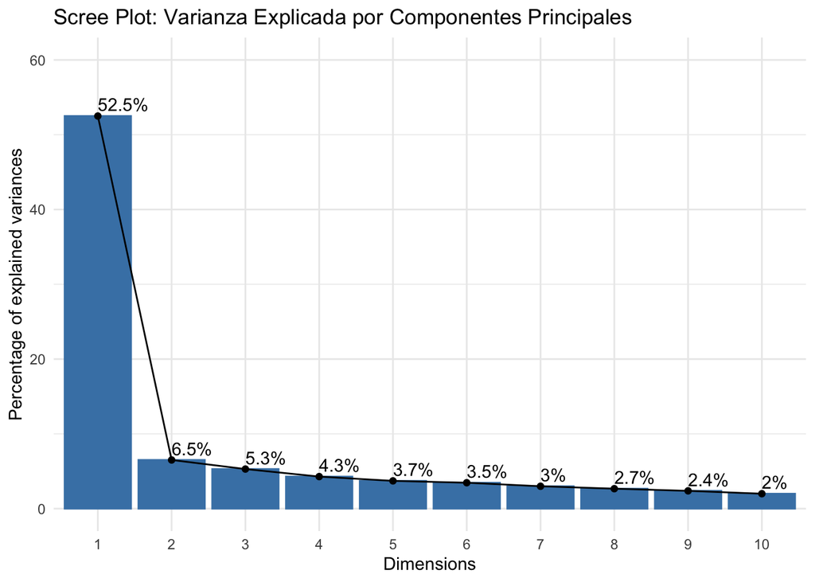

```r
# Scree plot: Una forma es generando un scree plot que represente los eigenvalores ordenador de mayor a menor.
# Con la función fviz_screeplot() del paquete factoextra podemos obtener esta representación, sin importar qué función hemos utilizado para generar los componentes principales

fviz_screeplot(pca_genes, addlabels = TRUE, ylim = c(0, 60))+
  ggtitle("Scree Plot: Varianza Explicada por Componentes Principales") +
  theme_minimal()
```

#### 2.1.3 Cargas factoriales del PCA

```r
# Extraer las cargas factoriales del PCA

cargas_pca <- as.data.frame(pca_genes$rotation)

# Seleccionar solo las primeras 5 dimensiones
cargas_pca <- cargas_pca[, 1:5]  # Selecciona los primeros 5 componentes principales


# Añadir una columna con los nombres de las variables
cargas_pca <- cbind(Variable = rownames(cargas_pca), cargas_pca)

# Redondear valores a 1 decimales para mayor claridad
cargas_pca <- cargas_pca %>% mutate(across(where(is.numeric), ~ round(.x, 1)))



# Ver primeras filas de la tabla
head(cargas_pca)
```

```
##            Variable  PC1  PC2  PC3  PC4  PC5
## AQ_ADIPOQ AQ_ADIPOQ  0.0  0.1 -0.2  0.6 -0.1
## AQ_ALOX5   AQ_ALOX5 -0.2 -0.1  0.0  0.0 -0.2
## AQ_ARG1     AQ_ARG1 -0.1 -0.4  0.1  0.0  0.0
## AQ_BMP2     AQ_BMP2 -0.1 -0.1  0.0  0.1  0.3
## AQ_CCL2     AQ_CCL2 -0.1  0.3 -0.1 -0.1 -0.1
## AQ_CCL5     AQ_CCL5 -0.2  0.0  0.1  0.1  0.0
```

Ahora hago la tabla de estas cargas

```r
# Crear tabla con gt
tabla_pca_cargas <- cargas_pca %>%
  gt() %>%
  tab_header(
    title = md("**Tabla PCA cargas.** *Cargas de los componentes principales*")
  ) %>%
  tab_style(
    style = cell_fill(color = "lightblue"),
    locations = cells_column_labels()
  ) %>%
  tab_style(
    style = cell_text(weight = "bold"),
    locations = cells_body(columns =  c("Variable", "PC1", "PC2", "PC3", "PC4", "PC5"))
  ) %>%
  tab_style(
    style = cell_borders(sides = "top", color = "blue", weight = px(2)),
    locations = cells_body()
  ) %>%
  tab_source_note(
    source_note = md("*Fuente: Análisis PCA sobre los datos de expresión génica*")
  )

# Mostrar la tabla en la consola
tabla_pca_cargas
```

**Tabla PCA cargas.** *Cargas de los componentes principales*

| Variable | PC1 | PC2 | PC3 | PC4 | PC5 |
| --- | --- | --- | --- | --- | --- |
| AQ_ADIPOQ | 0.0 | 0.1 | -0.2 | 0.6 | -0.1 |
| AQ_ALOX5 | -0.2 | -0.1 | 0.0 | 0.0 | -0.2 |
| AQ_ARG1 | -0.1 | -0.4 | 0.1 | 0.0 | 0.0 |
| AQ_BMP2 | -0.1 | -0.1 | 0.0 | 0.1 | 0.3 |
| AQ_CCL2 | -0.1 | 0.3 | -0.1 | -0.1 | -0.1 |
| AQ_CCL5 | -0.2 | 0.0 | 0.1 | 0.1 | 0.0 |
| AQ_CCR5 | -0.2 | 0.1 | 0.1 | 0.1 | -0.1 |
| AQ_CD274 | -0.2 | -0.1 | 0.0 | 0.0 | 0.0 |
| AQ_CD36 | -0.2 | 0.0 | 0.0 | 0.0 | -0.1 |
| AQ_CHKA | -0.1 | 0.1 | 0.3 | 0.1 | 0.1 |
| AQ_CPT1A | -0.2 | 0.2 | 0.1 | 0.0 | -0.1 |
| AQ_CSF2 | -0.1 | 0.1 | 0.0 | 0.0 | 0.4 |
| AQ_CXCR1 | -0.1 | -0.2 | -0.2 | 0.0 | 0.1 |
| AQ_FASN | -0.2 | 0.2 | 0.0 | 0.0 | 0.1 |
| AQ_FOXO3 | -0.1 | -0.1 | 0.3 | 0.0 | -0.2 |
| AQ_FOXP3 | -0.1 | 0.3 | -0.1 | -0.1 | -0.1 |
| AQ_G6PD | -0.2 | -0.1 | 0.2 | 0.1 | -0.1 |
| AQ_GPD2 | -0.2 | 0.2 | 0.1 | 0.1 | 0.0 |
| AQ_GPX1 | -0.1 | -0.1 | 0.1 | -0.1 | 0.0 |
| AQ_IFNG | -0.2 | 0.0 | 0.0 | 0.1 | 0.1 |
| AQ_IL10 | -0.1 | -0.3 | -0.2 | 0.0 | -0.1 |
| AQ_IL1B | -0.2 | -0.2 | -0.2 | 0.0 | 0.1 |
| AQ_IL6 | -0.1 | 0.0 | 0.0 | 0.1 | 0.4 |
| AQ_IRS1 | -0.1 | 0.1 | 0.1 | -0.1 | -0.1 |
| AQ_JAK1 | -0.2 | 0.1 | 0.0 | 0.0 | 0.1 |
| AQ_JAK3 | -0.1 | -0.2 | -0.3 | 0.0 | 0.0 |
| AQ_LDHA | -0.2 | 0.1 | 0.0 | 0.0 | 0.0 |
| AQ_LIF | -0.1 | 0.3 | 0.1 | 0.0 | 0.1 |
| AQ_MAPK1 | -0.2 | -0.1 | 0.1 | 0.0 | 0.0 |
| AQ_NFE2L2 | -0.2 | 0.0 | 0.0 | 0.0 | 0.0 |
| AQ_NFKB1 | -0.2 | 0.0 | 0.0 | 0.0 | 0.1 |
| AQ_NLRP3 | -0.2 | 0.0 | -0.1 | -0.1 | -0.2 |
| AQ_NOS2 | -0.1 | 0.1 | -0.3 | -0.2 | -0.3 |
| AQ_NOX5 | 0.0 | 0.1 | -0.2 | 0.6 | -0.1 |
| AQ_PDCD1 | -0.1 | 0.1 | 0.0 | 0.1 | -0.1 |
| AQ_PPARG | -0.1 | -0.2 | 0.0 | 0.1 | -0.2 |
| AQ_PTAFR | -0.2 | -0.2 | 0.0 | 0.0 | 0.0 |
| AQ_PTGS2 | -0.2 | -0.1 | 0.2 | 0.1 | 0.0 |
| AQ_SLC2A4 | 0.0 | -0.3 | 0.3 | 0.0 | -0.2 |
| AQ_SOD1 | -0.2 | 0.1 | 0.1 | 0.0 | 0.0 |
| AQ_SREBF1 | -0.2 | 0.1 | 0.0 | 0.0 | 0.1 |
| AQ_STAT3 | -0.2 | 0.1 | -0.3 | -0.1 | -0.1 |
| AQ_TGFB1 | -0.2 | 0.0 | -0.1 | 0.0 | 0.0 |
| AQ_TLR3 | -0.2 | -0.1 | 0.0 | 0.2 | 0.1 |
| AQ_TLR4 | -0.2 | -0.2 | -0.2 | 0.0 | 0.0 |
| AQ_TNF | -0.2 | -0.1 | -0.2 | -0.1 | -0.1 |

*Fuente: Análisis PCA sobre los datos de expresión génica*

#### 2.1.4 Contribucion y calidad de las variables al modelo

```r
# Graficas de variables
var <- get_pca_var(pca_genes)        # A partir de esto podemos extraer informacion de qué genes tienen más impacto en cada componente principal
var
```

```
## Principal Component Analysis Results for variables
##  ===================================================
##   Name       Description
## 1 "$coord"   "Coordinates for the variables"
## 2 "$cor"     "Correlations between variables and dimensions"
## 3 "$cos2"    "Cos2 for the variables"
## 4 "$contrib" "contributions of the variables"
```

```r
head(var$cor)                        # Correlación entre los genes y los componentes principales
```

```
##                Dim.1       Dim.2       Dim.3        Dim.4       Dim.5
## AQ_ADIPOQ  0.1749096  0.10319180 -0.31400820  0.864043553 -0.16391601
## AQ_ALOX5  -0.7988032 -0.15439682 -0.02965741  0.019083982 -0.20707009
## AQ_ARG1   -0.3027770 -0.64478579  0.13645610 -0.006181647  0.05350082
## AQ_BMP2   -0.6045039 -0.16953246  0.03327501  0.073333966  0.39751999
## AQ_CCL2   -0.5332813  0.58717607 -0.23061891 -0.202585618 -0.11038903
## AQ_CCL5   -0.9046767  0.05107928  0.13033365  0.083379621  0.06325736
##                 Dim.6        Dim.7       Dim.8       Dim.9      Dim.10
## AQ_ADIPOQ  0.26060831 -0.105667892  0.05267440 -0.04659474  0.01430448
## AQ_ALOX5  -0.04794972  0.267530552 -0.04104378 -0.01188500  0.09744667
## AQ_ARG1    0.21315063  0.144964430  0.43725065 -0.30311017 -0.01282096
## AQ_BMP2    0.11009178  0.038858389  0.03897407 -0.27730240 -0.45688163
## AQ_CCL2    0.08715814 -0.008729754  0.14844059 -0.13291655  0.05819962
## AQ_CCL5    0.14060128  0.092327100 -0.05456648  0.11190206  0.01664485
##                Dim.11       Dim.12      Dim.13       Dim.14        Dim.15
## AQ_ADIPOQ -0.04174990  0.005752533 -0.01348128  0.008339635 -0.0004985933
## AQ_ALOX5  -0.12999681 -0.329064037 -0.14292805 -0.086207388 -0.1120546647
## AQ_ARG1   -0.11134832  0.186035380  0.04551078 -0.127894218  0.0098865879
## AQ_BMP2    0.03372206 -0.182795448  0.25936142 -0.060658155 -0.0030319898
## AQ_CCL2   -0.26415644  0.049917869  0.12239761  0.083873418  0.2093928959
## AQ_CCL5    0.16882002  0.092358947 -0.10479465 -0.016090668  0.0336713408
##                  Dim.16       Dim.17        Dim.18       Dim.19       Dim.20
## AQ_ADIPOQ -0.0001054854  0.003859779 -0.0004115203 -0.002422493  0.015642358
## AQ_ALOX5   0.0690392383 -0.096591618  0.0717518024  0.047971965  0.034685581
## AQ_ARG1   -0.0654761409  0.031093452  0.0821284670 -0.076036482 -0.025346734
## AQ_BMP2   -0.0176555758  0.089392160 -0.0527689710  0.009375696 -0.005832009
## AQ_CCL2   -0.1310123091  0.001477520  0.0207400437 -0.037254199 -0.177319014
## AQ_CCL5   -0.0451999237  0.089232855 -0.0477478478 -0.018025481 -0.035835225
##                  Dim.21       Dim.22       Dim.23       Dim.24       Dim.25
## AQ_ADIPOQ  0.0004950838  0.008166405 -0.002486545 -0.006234994  0.005267112
## AQ_ALOX5   0.0305683989  0.015463320  0.006834090 -0.066900621 -0.017661767
## AQ_ARG1   -0.0391977715  0.110072740 -0.049274691  0.077044246 -0.029308442
## AQ_BMP2   -0.0910843239  0.010947432  0.002599888  0.004699026  0.052409580
## AQ_CCL2    0.0395096811 -0.040575680 -0.008303207 -0.046218585  0.011365998
## AQ_CCL5   -0.0551535058  0.017933080  0.047961323  0.051698690 -0.060013939
##                  Dim.26        Dim.27        Dim.28       Dim.29        Dim.30
## AQ_ADIPOQ  0.0005276109 -0.0002078945 -0.0008291021 -0.006410032  0.0004430446
## AQ_ALOX5   0.0436685908  0.0200875234  0.0102800053  0.033639993  0.0200457034
## AQ_ARG1    0.0573484940  0.0083341667  0.0094624330  0.071568153 -0.0463547513
## AQ_BMP2   -0.0136790892 -0.0135943151 -0.0421624282 -0.024556562  0.0392324705
```

[output cut: 15 more lines]

```
## AQ_CCL5    0.0381043809 -0.006792407 -3.455654e-02 -0.0031132230  0.0181693812
##                  Dim.41        Dim.42        Dim.43        Dim.44        Dim.45
## AQ_ADIPOQ  0.0004499283  0.0001750192  0.0001779830  0.0001430669  7.079664e-05
## AQ_ALOX5   0.0063918802 -0.0218969731  0.0017169954 -0.0136188988 -2.522525e-03
## AQ_ARG1   -0.0040266048 -0.0001657315  0.0009317229  0.0024529367 -3.320301e-03
## AQ_BMP2    0.0019079666 -0.0040347594 -0.0021939168  0.0024877945  1.065822e-04
## AQ_CCL2    0.0234791642  0.0001143219 -0.0009576847  0.0010687176  7.846981e-03
## AQ_CCL5   -0.0058753616  0.0087658649 -0.0114589387 -0.0083692095 -8.523181e-03
##                  Dim.46
## AQ_ADIPOQ  7.365056e-09
## AQ_ALOX5   3.237729e-16
## AQ_ARG1    1.167534e-16
## AQ_BMP2   -1.697858e-17
## AQ_CCL2    6.719808e-18
## AQ_CCL5   -5.531330e-17
```

```r
head(var$cos2)                       # Calidad en el mapa de factores -mide qué tan bien se proyectan las variables en los componentes principales-
```

```
##                Dim.1       Dim.2        Dim.3        Dim.4       Dim.5
## AQ_ADIPOQ 0.03059337 0.010648548 0.0986011478 7.465713e-01 0.026868457
## AQ_ALOX5  0.63808651 0.023838378 0.0008795622 3.641984e-04 0.042878024
## AQ_ARG1   0.09167390 0.415748710 0.0186202683 3.821276e-05 0.002862337
## AQ_BMP2   0.36542497 0.028741255 0.0011072263 5.377871e-03 0.158022140
## AQ_CCL2   0.28438897 0.344775735 0.0531850826 4.104093e-02 0.012185737
## AQ_CCL5   0.81843987 0.002609093 0.0169868613 6.952161e-03 0.004001494
##                 Dim.6        Dim.7       Dim.8        Dim.9       Dim.10
## AQ_ADIPOQ 0.067916692 0.0111657034 0.002774592 0.0021710696 0.0002046181
## AQ_ALOX5  0.002299176 0.0715725960 0.001684592 0.0001412531 0.0094958536
## AQ_ARG1   0.045433192 0.0210146860 0.191188130 0.0918757760 0.0001643770
## AQ_BMP2   0.012120200 0.0015099744 0.001518978 0.0768966223 0.2087408223
## AQ_CCL2   0.007596542 0.0000762086 0.022034609 0.0176668103 0.0033871957
## AQ_CCL5   0.019768720 0.0085242934 0.002977501 0.0125220704 0.0002770511
##                Dim.11       Dim.12       Dim.13       Dim.14       Dim.15
## AQ_ADIPOQ 0.001743054 3.309163e-05 0.0001817448 6.954952e-05 2.485953e-07
## AQ_ALOX5  0.016899171 1.082831e-01 0.0204284261 7.431714e-03 1.255625e-02
## AQ_ARG1   0.012398447 3.460916e-02 0.0020712308 1.635693e-02 9.774462e-05
## AQ_BMP2   0.001137177 3.341418e-02 0.0672683484 3.679412e-03 9.192962e-06
## AQ_CCL2   0.069778626 2.491794e-03 0.0149811748 7.034750e-03 4.384538e-02
## AQ_CCL5   0.028500200 8.530175e-03 0.0109819196 2.589096e-04 1.133759e-03
##                 Dim.16       Dim.17       Dim.18       Dim.19       Dim.20
## AQ_ADIPOQ 1.112717e-08 1.489790e-05 1.693490e-07 5.868472e-06 2.446834e-04
## AQ_ALOX5  4.766416e-03 9.329941e-03 5.148321e-03 2.301309e-03 1.203089e-03
## AQ_ARG1   4.287125e-03 9.668027e-04 6.745085e-03 5.781547e-03 6.424569e-04
## AQ_BMP2   3.117194e-04 7.990958e-03 2.784564e-03 8.790367e-05 3.401233e-05
## AQ_CCL2   1.716423e-02 2.183065e-06 4.301494e-04 1.387875e-03 3.144203e-02
## AQ_CCL5   2.043033e-03 7.962502e-03 2.279857e-03 3.249180e-04 1.284163e-03
##                 Dim.21       Dim.22       Dim.23       Dim.24       Dim.25
## AQ_ADIPOQ 2.451080e-07 6.669017e-05 6.182905e-06 3.887515e-05 2.774246e-05
## AQ_ALOX5  9.344270e-04 2.391143e-04 4.670479e-05 4.475693e-03 3.119380e-04
## AQ_ARG1   1.536465e-03 1.211601e-02 2.427995e-03 5.935816e-03 8.589847e-04
## AQ_BMP2   8.296354e-03 1.198463e-04 6.759420e-06 2.208084e-05 2.746764e-03
## AQ_CCL2   1.561015e-03 1.646386e-03 6.894325e-05 2.136158e-03 1.291859e-04
## AQ_CCL5   3.041909e-03 3.215954e-04 2.300288e-03 2.672755e-03 3.601673e-03
##                 Dim.26       Dim.27       Dim.28       Dim.29       Dim.30
## AQ_ADIPOQ 2.783733e-07 4.322011e-08 6.874103e-07 4.108851e-05 1.962886e-07
## AQ_ALOX5  1.906946e-03 4.035086e-04 1.056785e-04 1.131649e-03 4.018302e-04
## AQ_ARG1   3.288850e-03 6.945834e-05 8.953764e-05 5.122001e-03 2.148763e-03
## AQ_BMP2   1.871175e-04 1.848054e-04 1.777670e-03 6.030247e-04 1.539187e-03
```

[output cut: 15 more lines]

```
## AQ_CCL5   1.451944e-03 4.613680e-05 1.194155e-03 9.692158e-06 3.301264e-04
##                 Dim.41       Dim.42       Dim.43       Dim.44       Dim.45
## AQ_ADIPOQ 2.024355e-07 3.063173e-08 3.167793e-08 2.046814e-08 5.012164e-09
## AQ_ALOX5  4.085613e-05 4.794774e-04 2.948073e-06 1.854744e-04 6.363135e-06
## AQ_ARG1   1.621355e-05 2.746695e-08 8.681076e-07 6.016899e-06 1.102440e-05
## AQ_BMP2   3.640336e-06 1.627928e-05 4.813271e-06 6.189121e-06 1.135976e-08
## AQ_CCL2   5.512712e-04 1.306949e-08 9.171600e-07 1.142157e-06 6.157511e-05
## AQ_CCL5   3.451987e-05 7.684039e-05 1.313073e-04 7.004367e-05 7.264461e-05
##                 Dim.46
## AQ_ADIPOQ 5.424405e-17
## AQ_ALOX5  1.048289e-31
## AQ_ARG1   1.363136e-32
## AQ_BMP2   2.882722e-34
## AQ_CCL2   4.515581e-35
## AQ_CCL5   3.059561e-33
```

**cos2** –> representa la calidad, mayor cos2 = mayor calidad de la variable = más importante **contrib** –> Contiene las contribuciones (en %) de las variables a los componentes principales

Ahora visualizamos esta correlacion entre genes y componentes principales

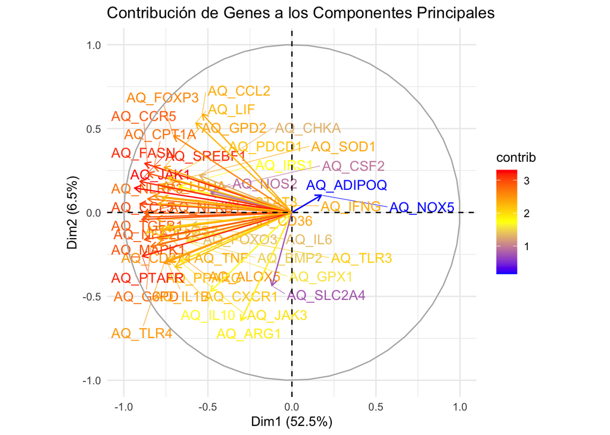

```r
fviz_pca_var(pca_genes,
             col.var = "contrib",   # Colorear según contribución
             gradient.cols = c("blue", "yellow", "red"),  # Mejor escala de colores
             repel = TRUE) +        # Evita solapamiento de etiquetas
  ggtitle("Contribución de Genes a los Componentes Principales") +
  theme_minimal()
```

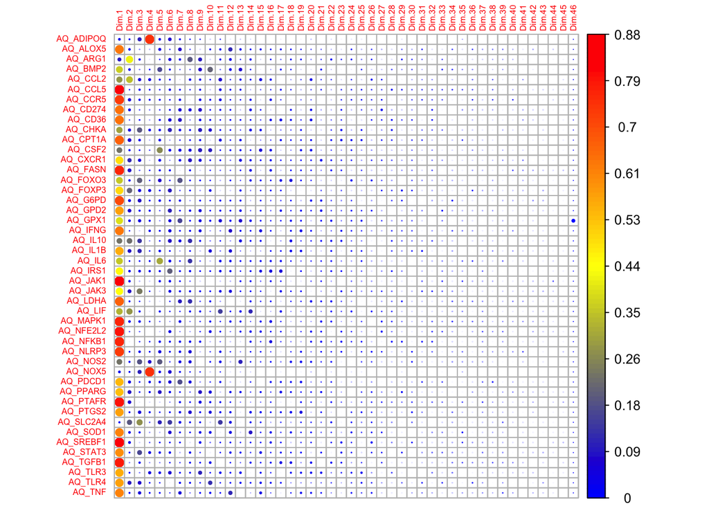

```r
# Graficar cos2 con separación del título

corrplot(var$cos2,
         is.corr = FALSE,
         col = colorRampPalette(c("blue", "yellow", "red"))(100), # Colores en gradiente
         tl.cex = 0.5,   # Reducir tamaño de etiquetas en el eje X
         cl.cex = 0.8)   # Ajustar tamaño de leyenda

# Agregar título separado del gráfico

title("Calidad de Representación (Cos2) en el PCA", line = 5, cex.main = 1.0)
```

#### 2.1.5 Contribucion

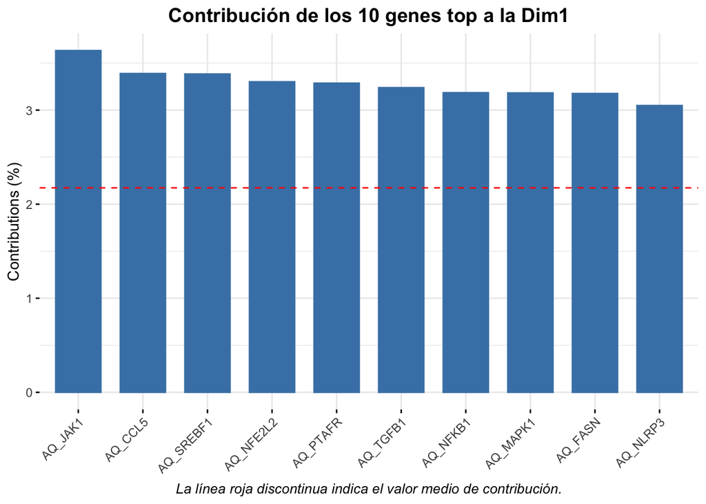

```r
# Contribución de variables: Top 10 variables
# La línea roja discontinua indica valor medio de contribución.

# Crear gráfico de contribución de variables al primer componente (Dim1)
contribucion_variables_dim1 <- fviz_contrib(pca_genes,
                                            choice = "var",
                                            axes = 1,
                                            top = 10) +
  ggtitle("Contribución de los 10 genes top a la Dim1") +  # Agregar título
  labs(caption = "La línea roja discontinua indica el valor medio de contribución.") +  #Agregar pie de figura
  theme(plot.title = element_text(hjust = 0.5, face = "bold", size = 14),  # Centrar título
        plot.caption = element_text(hjust = 0.5, size = 10, face = "italic"))  # Formato del pie de figura


contribucion_variables_dim1
```

De la grafica extraemos que las variables que más contribuyen a la Dimension 1 son: (busca info de cada una)

- JAK1: Este gen desempeña un papel crucial en la expresión de genes que median la inflamación, la remodelación epitelial y la progresión del cáncer metastásico. Este gen es un componente clave de la respuesta inmune e inflamatoria de la interleucina-6 (IL-6)/JAK1/STAT3
- CCL5: Se ha demostrado que este gen participa en el desarrollo y propagación de las células cancerígenas, para ello, las células cancerígenas revierten la acción de este gen para usarlo en contra del paciente formando un microambiente supresor
- SREBF1:Necesaria para la respuesta inmune innata en los macrófagos al regular el metabolismo lipídico
- NFE2L2:Codifican proteínas involucradas en la respuesta a lesiones e inflamaciones, que incluye la producción de radicales libres.La activación de NFE2L2 se ha relacionado con la quimiorresistencia en modelos de líneas celulares. Recientemente, se ha descubierto que las mutaciones somáticas que activan NFE2L2, están asociadas con malos resultados en pacientes con cáncer de pulmón de células no pequeñas
- PTAFR :Este gen codifica un receptor acoplado a proteína G de siete transmembrana para el factor activador de plaquetas (PAF), el PAF es un fosfolípido que desempeña un papel importante en la transformación oncogénica, el crecimiento tumoral, la angiogénesis, la metástasis y los procesos proinflamatorios.
- TGFB1. En pacientes con cancer, las células tumorales se ha demostrado que inducen la formación de más TGFB1 con lo que consiguen suprimir aun mas la defensa inmunitaria del organismo
- NFKB1: El factor nuclear de transcripción NF-κB (1) es importante en muchas vías de señalización celular, participa en diversos procesos biológicos y sus alteraciones están asociadas a trastornos inmunitarios y cáncer, entre otras patologías. NF-κB se expresa en todos los tipos de células y tejidos, de tal forma que muchas mutaciones oncogénicas contribuyen a la activación de NF-κB en las células tumorales, y son nuevas rutas de investigación terapéuticas para el cáncer.
- MAPK1: MAPK1 promueve la metástasis y la invasión del cáncer gástrico como factor de transcripción bidireccional
- FASN: Codifica para una enzima que ayuda a las células cancerosas a crecer y resistir los ataques inmunitarios
- NLRP3: La desregulación de la activación del inflamasoma NLRP3 está implicada en la patogénesis tumoral, aunque su papel en el desarrollo y la progresión del cáncer sigue siendo controvertido debido a los hallazgos inconsistentes descritos

Sabiendo esto no es de extrañar que la actividad asociada a estos genes sea tan notoria en nuestra base de datos de pacientes con cancer

¿ Y para las 5 primeras dimensiones ?

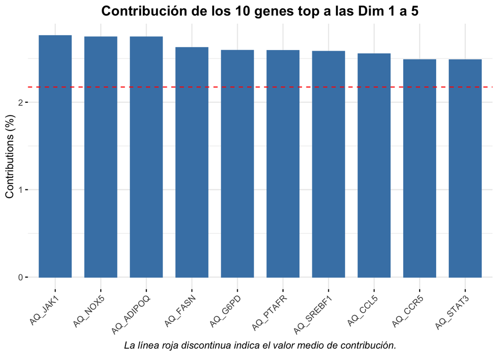

```r
# Crear gráfico
contribucion_variables_dim1_5 <- fviz_contrib(pca_genes,
                                              choice = "var",
                                              axes = 1:5,
                                              top = 10) +
  ggtitle("Contribución de los 10 genes top a las Dim 1 a 5") +  # Agregar título
  labs(caption = "La línea roja discontinua indica el valor medio de contribución.") +  #Agregar pie de figura
  theme(plot.title = element_text(hjust = 0.5, face = "bold", size = 14),  # Centrar título y ponerlo en negrita
        plot.caption = element_text(hjust = 0.5, size = 10, face = "italic"))  # Pie de figura en cursiva


contribucion_variables_dim1_5
```

Podemos apreciar que hay genes que si solo miramos la dimension1 no aparecen como es el caso del STA T3, NOX5, ADIPOQ y CCR5

- STAT3: La STAT3 es una oncoproteína que se encuentra activa de manera constitutiva en cerca del 70 % de los tumores sólidos y hematológicos, incluidos el mieloma múltiple, varios tipos de linfoma y leucemia, el cáncer de seno, cabeza y cuello, el cáncer de próstata, el carcinoma de ovario, el melanoma, el carcinoma renal, el colorrectal y los tumores del epitelio del timo
- NOX5: Gen ampliamente implicado en el desarrollo de tejidos cancerígenos y en la proliferación de carcinomas en distintas áreas del cuerpo
- ADIPOQ: Tiene una relación directa con el cáncer, y por lo que he encontrado, está especialmente relacionado con el cáncer de mama
- CCR5 : Este gen forma el eje CCL5/CCR5. Este eje se ha demosrtado que esta involucrado en la progresión del cáncer, incluido el crecimiento tumoral autocrino y paracrino, la remodelación y migración de la matriz extracelular, la expansión de células madre cancerosas, la reparación del daño del ADN, la reprogramación metabólica y la angiogénesis

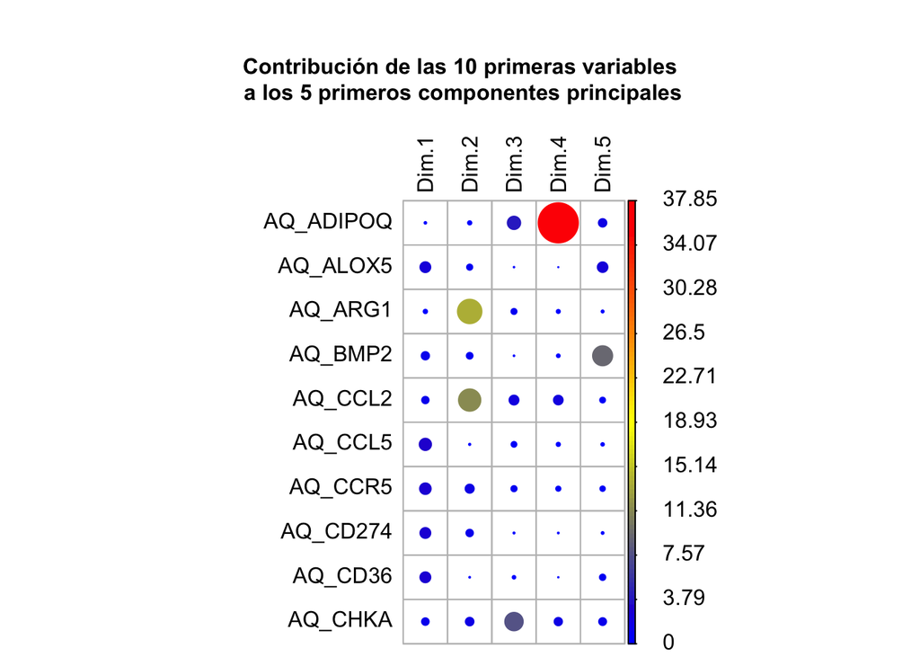

```r
# Contribucion de las 10 primeras variables a los 5 primeros componentes principales

# Ajustar márgenes para dar más espacio al título y la leyenda
par(mar = c(5, 5, 8, 5))  # Márgenes más grandes arriba y a la derecha
par(oma = c(0, 0, 5, 0))  # Espacio adicional externo arriba

# Graficar la matriz de contribucion
corrplot(var$contrib[1:10, 1:5], is.corr = FALSE,
         method = "circle",
         cl.offset = 1.0,  # Separar la leyenda del gráfico
         cl.align.text = "l",  # Alinear valores de la leyenda a la derecha
         col = colorRampPalette(c("blue", "yellow", "red"))(100), # Mejor gradiente de colores
         tl.cex = 1,  # Hacer etiquetas más legibles
         tl.col = "black",  # Color de etiquetas en negro
         cl.cex = 1)  # Ajustar tamaño de la leyenda

# Agregar título más claro, separado del gráfico
mtext("Contribución de las 10 primeras variables\n a los 5 primeros componentes principales",
      side = 3, line = 9, cex = 1.0, font = 2)
```

#### 2.1.6 Calidad

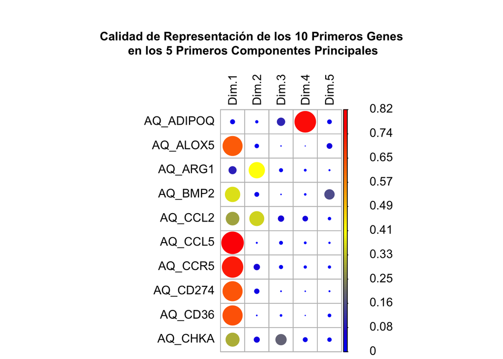

```r
# "Calidad" de las 10 primeras variables a los 5 primeros componentes principales


# Ajustar márgenes para dar más espacio al título y la leyenda
par(mar = c(5, 5, 8, 5))  # Márgenes más grandes arriba y a la derecha
par(oma = c(0, 0, 5, 0))  # Espacio adicional externo arriba

# Graficar la matriz de calidad de representación (cos2)
corrplot(var$cos2[1:10, 1:5],
         is.corr = FALSE,
         method = "circle",
         cl.offset = 1.5,  # Separar la leyenda del gráfico
         cl.align.text = "l",  # Alinear valores de la leyenda a la derecha
         col = colorRampPalette(c("blue", "yellow", "red"))(100), # Mejor gradiente de colores
         tl.cex = 1,  # Hacer etiquetas más legibles
         tl.col = "black",  # Color de etiquetas en negro
         cl.cex = 1)  # Ajustar tamaño de la leyenda

# Agregar título más claro, separado del gráfico
mtext("Calidad de Representación de los 10 Primeros Genes\n en los 5 Primeros Componentes Principales",
      side = 3, line = 9, cex = 1.0, font = 2)
```

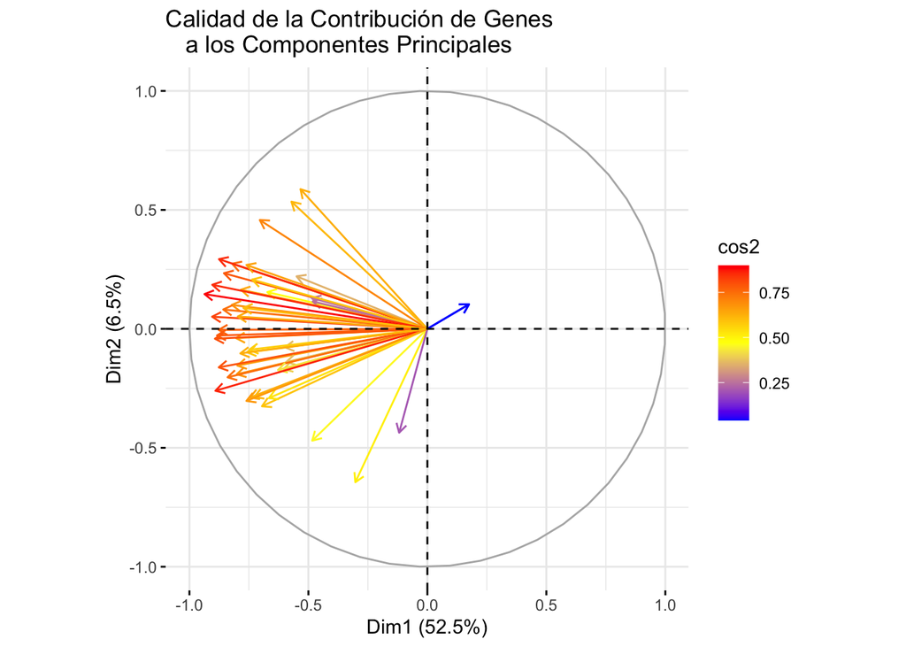

```r
fviz_pca_var(pca_genes,
             col.var = "cos2",   # Colorear según calidad de la contribucion
             geom.var = "arrow",
             gradient.cols = c("blue", "yellow", "red"),  # Mejor escala de colores
             repel = TRUE) +        # Evita solapamiento de etiquetas
  ggtitle("Calidad de la Contribución de Genes \n   a los Componentes Principales")
```

#### 2.1.7 Varianza explicada y acumulada

```r
# Proporción de varianza explicada y acumulada

PVE <- 100*pca_genes$sdev^2/sum(pca_genes$sdev^2)
PVE
```

```
##  [1] 5.249793e+01 6.509452e+00 5.295130e+00 4.287772e+00 3.713468e+00
##  [6] 3.466298e+00 2.995512e+00 2.667914e+00 2.380821e+00 1.998632e+00
## [11] 1.781150e+00 1.691499e+00 1.357553e+00 1.236762e+00 1.025908e+00
## [16] 9.208493e-01 8.189030e-01 7.127709e-01 6.676325e-01 6.262736e-01
## [21] 4.460295e-01 3.944572e-01 3.515606e-01 3.066081e-01 2.568690e-01
## [26] 2.444214e-01 2.001125e-01 1.738651e-01 1.547803e-01 1.272836e-01
## [31] 1.077100e-01 9.611286e-02 8.565501e-02 7.251177e-02 6.545374e-02
## [36] 6.148360e-02 4.362515e-02 4.080909e-02 3.538218e-02 2.767461e-02
## [41] 2.080080e-02 1.291548e-02 1.008617e-02 6.930923e-03 4.632197e-03
## [46] 2.358437e-16
```

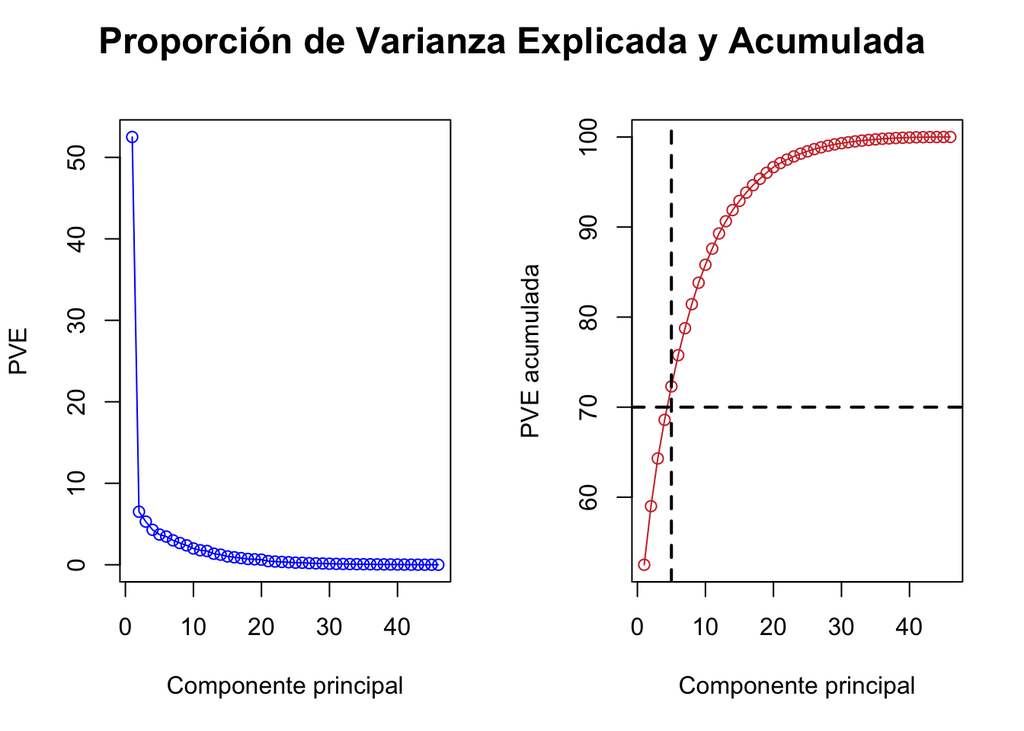

```r
par(mfrow = c(1,2))

plot(PVE, type = "o",
     ylab = "PVE",
     xlab = "Componente principal",
     col = "blue")
plot(cumsum(PVE), type = "o",
     ylab = "PVE acumulada",
     xlab = "Componente principal",
     col = "brown3")
abline(v = 5, col = "black", lty = 2, lwd = 2)
abline(h = 70, col = "black", lty = 2, lwd = 2)

mtext("Proporción de Varianza Explicada y Acumulada",
      side = 3, line = -2, outer = TRUE, font = 2, cex = 1.5)
```

De una forma mas visual se ve como solo el primer componente explica la amyor parte de la variacion y a medida que aumenta el numero de los componentes, menor es su contribucion al modelo. Se ve mejor al seleccionar solo los 5 primeros componentes y comprobar que ya se explica una cantidad proxima al 70% de la varianza total.

### 2.2. Aplicación del PCA y elecciones de componentes principales

#### 2.2.1 Graficar individuos

De la misma forma que antes con las variables ahora podemos extraer informacion de los individuos

```r
ind <- get_pca_ind(pca_genes)
ind
```

```
## Principal Component Analysis Results for individuals
##  ===================================================
##   Name       Description
## 1 "$coord"   "Coordinates for the individuals"
## 2 "$cos2"    "Cos2 for the individuals"
## 3 "$contrib" "contributions of the individuals"
```

De este modo las contribuciones de los individuos se podran reflejar de la siguiente forma

```r
head(ind$contrib)
```

```
##       Dim.1        Dim.2        Dim.3      Dim.4        Dim.5       Dim.6
## 1 1.6504835 0.0001682039 0.0007804333 0.10500145 0.0002704995 0.011025815
## 2 1.9186858 0.0459863684 0.0626298847 0.08885252 0.0098133887 0.139272082
## 3 0.3202199 2.3450814399 0.0299761359 0.08219106 1.1625204570 0.036572471
## 4 0.4663207 0.0103659083 0.5504082345 0.16066772 0.6521513561 0.220708573
## 5 1.2206941 0.0229965479 0.0016654319 0.03279003 0.0424884507 0.132055739
## 6 0.8601706 0.5144031492 0.0218533297 0.07015867 0.0409386329 0.004873407
##         Dim.7      Dim.8      Dim.9       Dim.10     Dim.11     Dim.12
## 1 0.054664380 0.26390564 0.11933246 9.020820e-03 0.02341493 0.06201758
## 2 0.219054997 0.09221433 0.06131388 1.503999e-06 0.18415698 0.02707368
## 3 1.064528648 1.48823653 5.31950200 2.196324e+00 1.26095425 0.29117728
## 4 0.372453694 0.26497245 0.44935072 1.928627e-02 0.57388189 0.01269932
## 5 0.002142102 0.18756176 0.42582438 1.836253e-02 0.19019583 0.02955306
## 6 0.063867738 0.36122415 1.14813121 9.147518e-03 0.01392066 0.49735891
##        Dim.13       Dim.14       Dim.15       Dim.16     Dim.17      Dim.18
```

[output cut: 41 more lines]

Asi como la calidad que podria verse asi

```r
  head(ind$cos2)
```

```
##       Dim.1        Dim.2        Dim.3       Dim.4        Dim.5        Dim.6
## 1 0.9674561 1.222527e-05 4.614136e-05 0.005026953 1.121564e-05 0.0004267313
## 2 0.9602499 2.853723e-03 3.161524e-03 0.003631948 3.474057e-04 0.0046022284
## 3 0.1771850 1.608936e-01 1.672972e-03 0.003714434 4.550056e-02 0.0013361543
## 4 0.5425286 1.495366e-03 6.458882e-02 0.015267082 5.366904e-02 0.0169543373
## 5 0.9336501 2.180932e-03 1.284809e-04 0.002048371 2.298718e-03 0.0066689623
## 6 0.7152853 5.303964e-02 1.832934e-03 0.004765028 2.408050e-03 0.0002675784
##          Dim.7       Dim.8      Dim.9       Dim.10       Dim.11       Dim.12
## 1 1.828325e-03 0.007861374 0.00317222 2.013060e-04 0.0004656625 0.0011712901
## 2 6.255506e-03 0.002345355 0.00139163 2.865621e-08 0.0031269934 0.0004365734
## 3 3.360971e-02 0.041848539 0.13348554 4.626640e-02 0.0236720744 0.0051911755
## 4 2.472516e-02 0.015666370 0.02370871 8.542339e-04 0.0226526398 0.0004760449
## 5 9.348593e-05 0.007290399 0.01477041 5.346879e-04 0.0049355626 0.0007282984
## 6 3.030436e-03 0.015265154 0.04329830 2.895933e-04 0.0003927470 0.0133258281
##         Dim.13       Dim.14       Dim.15       Dim.16       Dim.17       Dim.18
```

[output cut: 41 more lines]

Sin embargo estos datos asi no nos dicen mucho, vamos a probar otras formas mas visuales de representarlos

#### 2.2.2. Representación de las observaciones

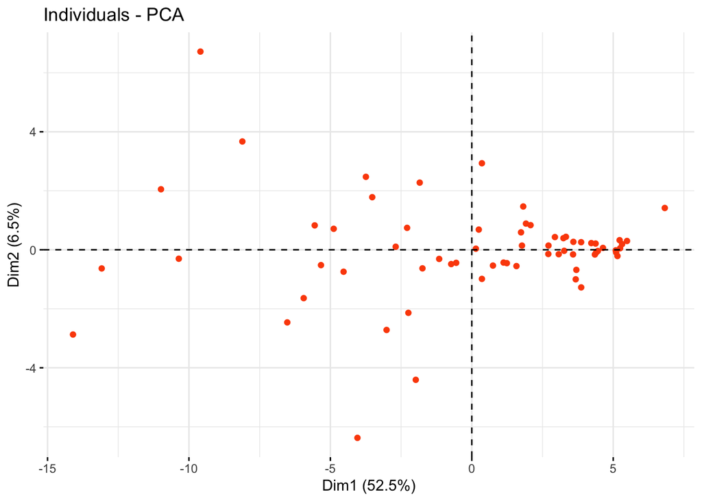

```r
# Coordenadas de los individuos en las dos primeras componentes
library(factoextra)

fviz_pca_ind(pca_genes, geom.ind = "point",
             col.ind = "#FC4E07",
             axes = c(1, 2),
             pointsize = 1.5)
```

En el grafico mostrado se ve la distribucion de los individuos en funcion de sus proyeciones (coordenadas) en las dos primeras dimensiones

Los ejes x e y (PC1 y PC2) son los ejes de la proyección de los datos. El primer componente principal (PC1) representa la dirección de máxima varianza en los datos, y el segundo componente (PC2) captura la mayor varianza restante, pero ortogonal a PC1

Vamos a graficar ahora en funcion de su calidad (cos2)

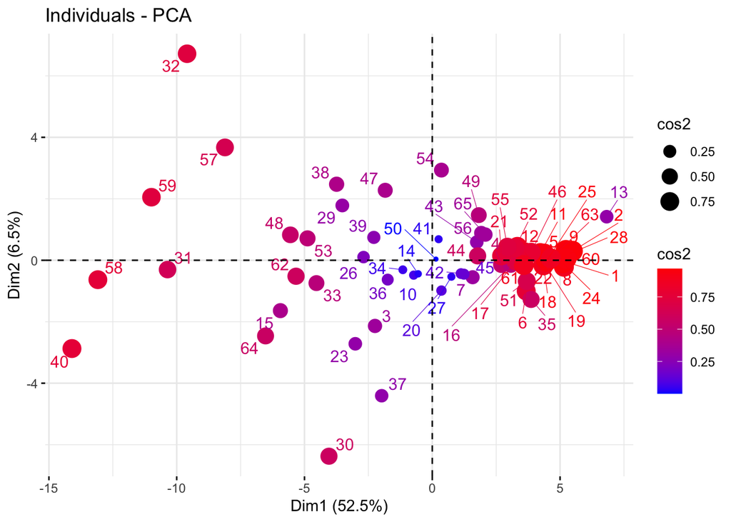

```r
# Calidad de los individuos

fviz_pca_ind(pca_genes, col.ind = "cos2", pointsize = "cos2",
gradient.cols = c("blue", "red"),
repel = TRUE )
```

Los individuos mas similares se agrupan

Aquellos con una menor “calidad” (menor valor de cos2) se muestran en azul mientras que los que mas calidad tienen se colorean en rojo

Se pueden ver individuos aislados quiza correspondientes a valores atipicos (ind.40, indv.32)

Por ultimo en funcion de su contribucion

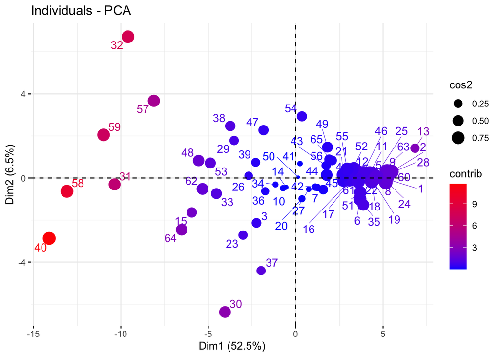

```r
# Contribucion de los individuos

fviz_pca_ind(pca_genes, col.ind = "contrib", pointsize = "cos2",
gradient.cols = c("blue", "red"),
repel = TRUE )
```

Para el caso de los indivuduos su contribucion y calidad a las dos primeras dimensiones es bastante diferente

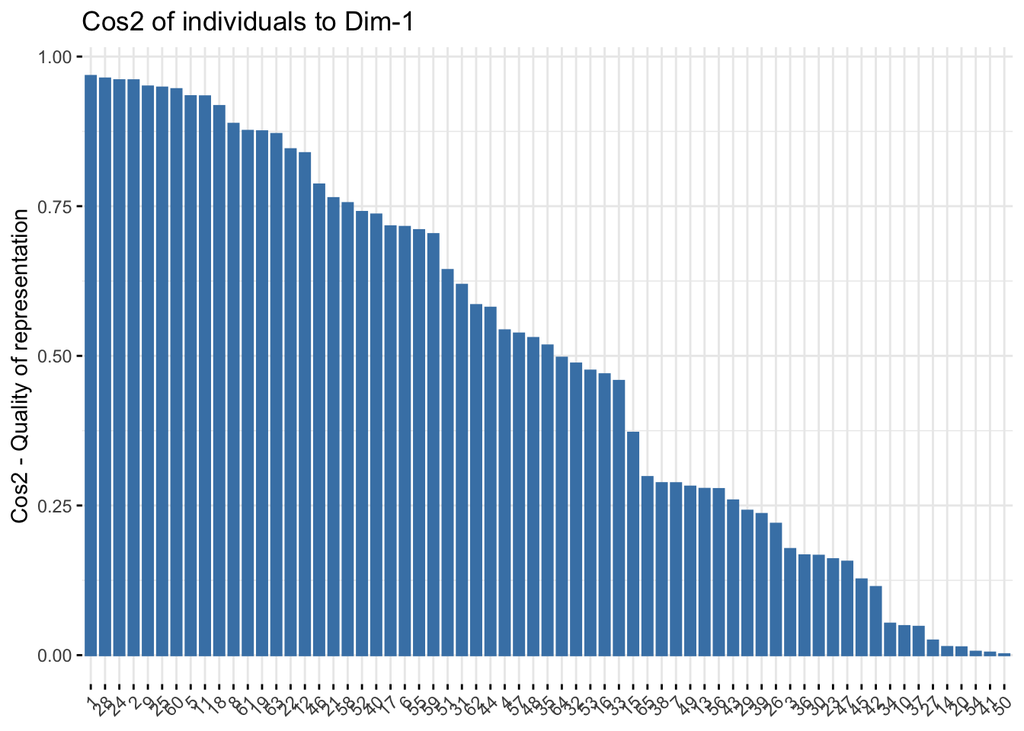

```r
fviz_cos2(pca_genes, choice = "ind")
```

#### 2.2.3 Biplot

Pese a que la funcion biplot solo puede ser útil cuando hay un número bajo de variables e individuos en el conjunto de datos ya que sino la trama final sera ilegible, vamos a representarlo igualmente

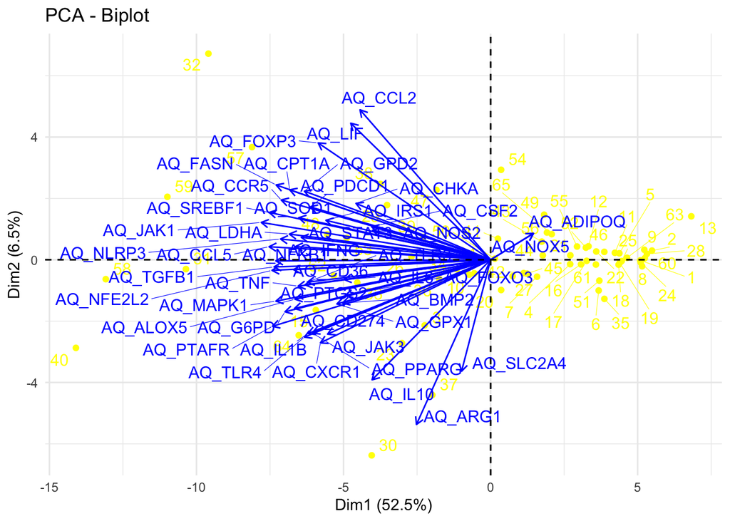

```r
fviz_pca_biplot(pca_genes, repel = TRUE,
                col.var = "blue",  # Color de las variables
                col.ind = "yellow"  # Color de los individuos
) + theme_minimal()
```

Le podemos añadir elipses que agrupen en funcion de una caracteristica como puede ser el tratamiento o tipo de cancer pero nuevamente al ser una base de datos “grande” es bastante poco intuitivo

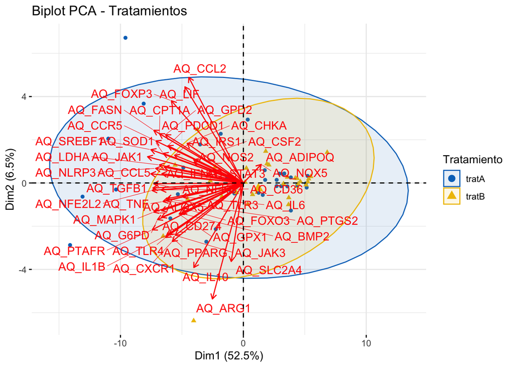

```r
fviz_pca_biplot(pca_genes,

col.ind = df$trat, palette = "jco",
addEllipses = TRUE, label = "var",
col.var = "red", repel = TRUE,
legend.title = "Tratamiento",
title = "Biplot PCA - Tratamientos")
```

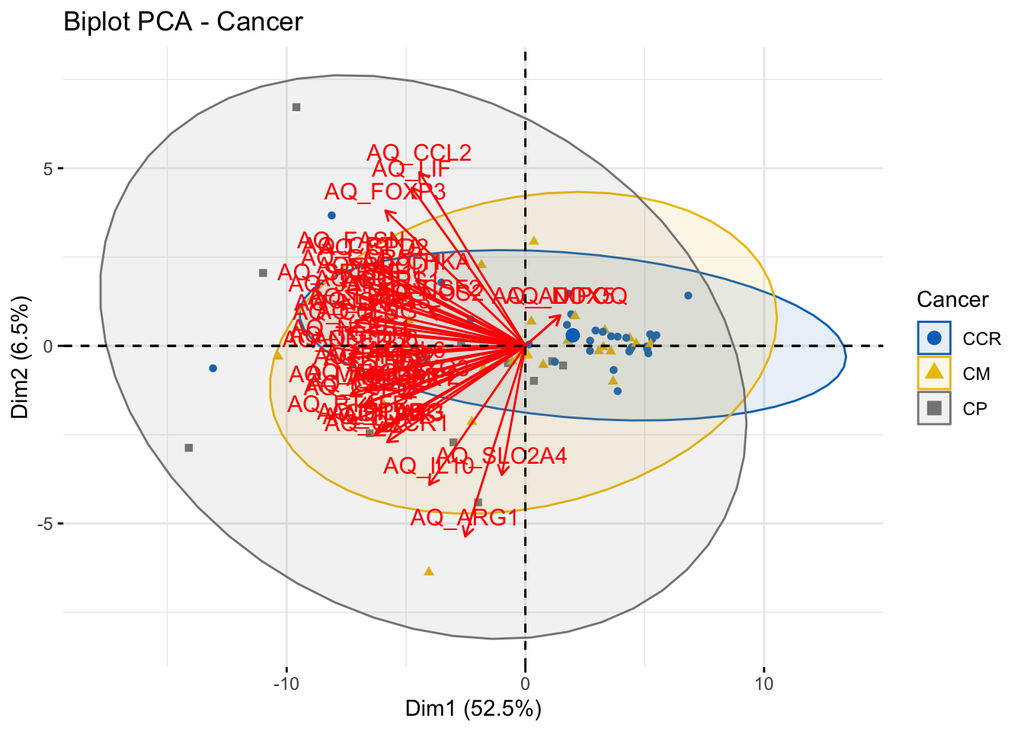

```r
fviz_pca_biplot(pca_genes,

col.ind = df$tumor, palette = "jco",
addEllipses = TRUE, label = "var",
col.var = "red", repel = F,
legend.title = "Cancer",
title = "Biplot PCA - Cancer")
```

En este caso podemos ver algunos genes que parecen destacar o tener mas presencia sobre algun tpo de tumor especifico

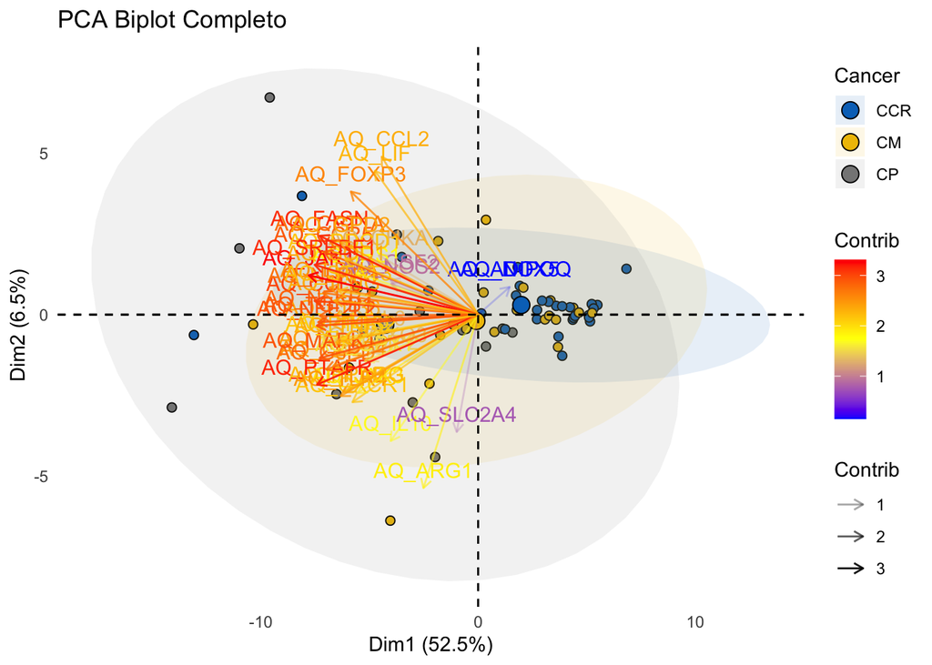

```r
fviz_pca_biplot(pca_genes,

                # Individuos
                geom.ind = "point",
                fill.ind = df$tumor, col.ind = "black",
                pointshape = 21, pointsize = 2,
                palette = "jco",
                addEllipses = TRUE,

                # Variables
                alpha.var = "contrib", col.var = "contrib",
                gradient.cols = c("blue", "yellow", "red"),
                legend.title = list(fill = "Cancer", color = "Contrib", alpha = "Contrib"),
                title = "PCA Biplot Completo") +
  theme_minimal() +  # Aplica un tema minimalista
  theme(panel.grid = element_blank())  # Elimina el grid de fondo
```

## 3. Tabla descriptiva de las variables más importantes

Para representar la tabla que nos piden:

```r
# 1. Sacamos cuartiles de cada componente a representar (2 componentes)
terciles_PC1 <- quantile(pca_genes$x[, 1], probs = c(1/3, 2/3))
terciles_PC2 <- quantile(pca_genes$x[, 2], probs = c(1/3, 2/3))

# 2. Para cada observacion, tenemos que indicar en qué percentil caen en cada una de las componentes (PC1 y PC2)
df$tercil_PC1 <- cut(pca_genes$x[, 1], breaks = c(-Inf, terciles_PC1, Inf), labels = c("t1", "t2", "t3"))
df$tercil_PC2 <- cut(pca_genes$x[, 2], breaks = c(-Inf, terciles_PC2, Inf), labels = c("t1", "t2", "t3"))

tabla2 <- data.frame()

get_stats <- function(x) {
  if (length(unique(x)) > 2 & all(!is.na(x))) {
    # Si es paramétrico, usamos la media y la desviación estándar
    return(c(mean = mean(x, na.rm = TRUE), sd = sd(x, na.rm = TRUE)))
  } else {
    # Si no es paramétrico, usamos la mediana y el rango intercuartílico
    return(c(median = median(x, na.rm = TRUE), IQR = IQR(x, na.rm = TRUE)))
  }
}

# Crear la tabla descriptiva para PC1 y PC2
for (pc in 1:2) {  # Para cada componente
  for (tercil in c("t1", "t2", "t3")) { # Para cada tercil
    # Subconjunto de datos para ese tercil y componente
    subset_data <- pca_genes$x[df[paste0("tercil_PC", pc)] == tercil]

    # Obtener estadísticas descriptivas
    stats <- get_stats(subset_data)

    # Guardar los resultados
    resultados <- rbind(resultados, c(Componente = paste0("PC", pc),
                                      Tercil = tercil,
                                      stats))
  }
}

# Dar formato a la tabla de resultados
colnames(resultados) <- c("Componente", "Tercil", "Media/Mediana", "Desviación Estándar/IQR")

# Mostrar la tabla resultante
resultados
```

[output not shown]

[output cut: 38 more lines]

```r
df_long <- df %>%
  pivot_longer(cols = starts_with("AQ_"),  # Cambia esto según el nombre de las columnas de tus genes
               names_to = "Gene",
               values_to = "Expression")

tabla_resumen <- df_long %>%
  tbl_summary(
    by = "tercil_PC1",  # Agrupamos por terciles del PC1 (o 'tercil_PC2' si quieres hacerlo por PC2),
    statistic = list(all_categorical() ~ "{n}"),
    digits = all_continuous() ~ c(2, 2),
    missing = "no"
  ) %>%
  add_p()
tabla_resumen
```

| **Characteristic** | **t1** N = 1,012<sup>1</sup> | **t2** N = 966<sup>1</sup> | **t3** N = 1,012<sup>1</sup> | **p-value**<sup>2</sup> |
| --- | --- | --- | --- | --- |
| X | 39.50 (32.00, 55.00) | 44.00 (21.00, 52.00) | 19.50 (9.00, 37.00) | <0.001 |
| id | 39.50 (32.00, 55.00) | 44.00 (21.00, 52.00) | 19.50 (9.00, 37.00) | <0.001 |
| edad | 65.05 (59.46, 74.70) | 72.21 (57.62, 77.16) | 61.38 (51.44, 72.49) | <0.001 |
| sexo |  |  |  | 0.11 |
| mujer | 598 | 598 | 644 |  |
| varon | 414 | 368 | 368 |  |
| exfumador |  |  |  | <0.001 |
| no | 598 | 368 | 598 |  |
| si | 414 | 598 | 414 |  |
| hta |  |  |  | <0.001 |
| no | 690 | 506 | 598 |  |
| si | 322 | 460 | 414 |  |
| dm |  |  |  | <0.001 |
| no | 874 | 782 | 782 |  |
| si | 138 | 184 | 230 |  |
| alergia |  |  |  | <0.001 |
| no | 874 | 828 | 966 |  |
| si | 138 | 138 | 46 |  |
| cardiopatia |  |  |  | 0.9 |
| no | 874 | 828 | 874 |  |
| si | 138 | 138 | 138 |  |
| ETE |  |  |  | <0.001 |
| no | 920 | 782 | 966 |  |
| si | 92 | 184 | 46 |  |
| neumopatia |  |  |  | <0.001 |
| no | 828 | 782 | 736 |  |
| si | 184 | 184 | 276 |  |
| hepatopatia |  |  |  | <0.001 |
| no | 920 | 966 | 966 |  |
| si | 92 | 0 | 46 |  |

[output cut: 155 more lines]

<sup>1</sup> Median (Q1, Q3); n  
<sup>2</sup> Kruskal-Wallis rank sum test; Pearson’s Chi-squared test

## 4. Implementar un modelo de regresión logística

La regresión logística es un modelo estadístico ampliamente utilizado en la biomedicina para anilizar factores de riesgo y predecir eventos clínicos. Esta busca modelar la relación entre una variable de resultado binaria y un conjunto de variables predictoras.

En primero lugar, transformaremos la variable ‘Extension’ en una respuesta binomial (si y no). Es decir, en caso de que haya metástatisis será ‘si’ y de ser regional o localizado corresponderá a ‘no’.

```r
df <- df %>%
  mutate(extension = ifelse(extension == "metastasico", "Si", "No"))
```

### 4.1. Metástasis vs PCA - sexo - trat - tumor

Tomamos para este primer ejemplo los dos primeros PCA, ya que, como hemos visto anteriormente, son los que representan la mayor varianza de los datos. También aplicaremos las variables sexo, tratamiento y tumor, ya que son variables que pueden influir en la metástatis tumoral.

```r
# Agreamos los PC1 y PC2 al dataframe inicial.
# Creamos los terciles (T1, T2, T3) de los dos primeros componentes

df$PC1 <- pca_genes$x[, 1]
df$PC2 <- pca_genes$x[, 2]

df <- df %>%
    mutate(tercil_PC1 = cut(PC1, breaks = quantile(PC1, probs = c(0, 1/3, 2/3, 1), na.rm = TRUE),
                      include.lowest = TRUE, labels = c("T1", "T2", "T3")),
    tercil_PC2 = cut(PC2, breaks = quantile(PC2, probs = c(0, 1/3, 2/3, 1), na.rm = TRUE),
                      include.lowest = TRUE, labels = c("T1", "T2", "T3")),
  )

#Convertimos a factor las variables categóricas que vayamos a utilizar en el modelo de regresión

df$extension <- as.factor(df$extension)
df$sexo <- as.factor(df$sexo)
df$trat <- as.factor(df$trat)
df$tumor <- as.factor(df$tumor)

# Aplicamos el modelo de regresion

modelo_regresion <- glm(extension ~ tercil_PC1 + tercil_PC2 + sexo + trat+ tumor, data = df, family = binomial)

summary(modelo_regresion) # Resumen del modelo
```

```
##
## Call:
## glm(formula = extension ~ tercil_PC1 + tercil_PC2 + sexo + trat +
##     tumor, family = binomial, data = df)
##
## Coefficients:
##              Estimate Std. Error z value Pr(>|z|)
## (Intercept)    0.4076     0.9133   0.446    0.655
## tercil_PC1T2  -0.2472     0.7272  -0.340    0.734
## tercil_PC1T3   0.4637     0.9194   0.504    0.614
## tercil_PC2T2   0.5532     0.8515   0.650    0.516
## tercil_PC2T3  -0.3012     0.7299  -0.413    0.680
## sexovaron      0.8673     0.6507   1.333    0.183
## trattratB     -0.6141     0.6123  -1.003    0.316
## tumorCM        0.9139     0.7220   1.266    0.206
## tumorCP        0.7433     0.9374   0.793    0.428
##
## (Dispersion parameter for binomial family taken to be 1)
##
##     Null deviance: 76.703  on 64  degrees of freedom
## Residual deviance: 70.584  on 56  degrees of freedom
## AIC: 88.584
##
## Number of Fisher Scoring iterations: 4
```

```r
coef_exponenciados <-  exp(coef(modelo_regresion))
conf_intervalos <- exp(confint(modelo_regresion))
valores_p <- summary(modelo_regresion)$coefficients[, 4] #Esto corresponde a la columna de valores p

# Con levels, podemos ver que resultado de cada variable coge como referencia (0) el modelo.

levels(df$extension)
```

```
## [1] "No" "Si"
```

```r
levels(df$sexo)
```

```
## [1] "mujer" "varon"
```

```r
levels(df$trat)
```

```
## [1] "tratA" "tratB"
```

```r
levels(df$tumor)
```

```
## [1] "CCR" "CM"  "CP"
```

El modelo de regresión nos devuelve datos de los intervalos de confianza y valores p, que son relevantes a la hora de analizar si las variables independientes que hemos incorporado al modelo tienen a aumentar, disminuir o mantener el riesgo de que se produzca metátastis del tumor.

Incorporaremos todos los datos en un *dataframe*, para después visualizarlos en una tabla.

```r
#Generamos un df con los resultados más relevantes.

resultados_tabla <- data.frame(
 Variable =rownames(summary(modelo_regresion)$coefficients),
 OR = sprintf("%.2f", coef_exponenciados),
 IC_95 = sprintf("(%.2f - %.2f)", conf_intervalos[,1], conf_intervalos[,2]),
 P_valor = sprintf("%.3f", valores_p)
)

tabla_resultados <- resultados_tabla %>%
  mutate(`OR (IC 95%)` = paste(OR, IC_95)) %>%  # Combinar OR e IC 95%
  select(Variable, `OR (IC 95%)`, P_valor) %>%  # Seleccionar columnas en el orden correcto
  rename("P value" = P_valor) %>%  # Renombrar columna de p-valor
  gt() %>%
  tab_header(
    title = md("**Tabla de regresión logística**"),
    subtitle = md("*Efecto de diversas variables*")
  ) %>%
  cols_align(align = "center", columns = c("OR (IC 95%)", "P value")) %>%
  tab_options(
    table.font.names = "Arial",
    column_labels.font.weight = "bold",
    heading.align = "left"
  ) %>%
  tab_footnote(
    footnote = "Fuente: Elaboración propia.  IC = Intervalo de Confianza.",
    locations = cells_body(columns = everything())
    # OR, if you want it only for the OR column:
    # locations = cells_body(columns = `OR (IC 95%)`)
  )

tabla_resultados
```

**Tabla de regresión logística**

*Efecto de diversas variables*

| Variable | OR (IC 95%) | P value |
| --- | --- | --- |
| (Intercept)<sup>1</sup> | 1.50 (0.25 - 9.81)<sup>1</sup> | 0.655<sup>1</sup> |
| tercil_PC1T2<sup>1</sup> | 0.78 (0.18 - 3.31)<sup>1</sup> | 0.734<sup>1</sup> |
| tercil_PC1T3<sup>1</sup> | 1.59 (0.26 - 10.22)<sup>1</sup> | 0.614<sup>1</sup> |
| tercil_PC2T2<sup>1</sup> | 1.74 (0.33 - 9.92)<sup>1</sup> | 0.516<sup>1</sup> |
| tercil_PC2T3<sup>1</sup> | 0.74 (0.17 - 3.13)<sup>1</sup> | 0.680<sup>1</sup> |
| sexovaron<sup>1</sup> | 2.38 (0.70 - 9.29)<sup>1</sup> | 0.183<sup>1</sup> |
| trattratB<sup>1</sup> | 0.54 (0.16 - 1.77)<sup>1</sup> | 0.316<sup>1</sup> |
| tumorCM<sup>1</sup> | 2.49 (0.64 - 11.29)<sup>1</sup> | 0.206<sup>1</sup> |
| tumorCP<sup>1</sup> | 2.10 (0.34 - 14.62)<sup>1</sup> | 0.428<sup>1</sup> |

<sup>1</sup> Fuente: Elaboración propia. IC = Intervalo de Confianza.

Esta tabla presenta los resultados de una regresión logística, donde representamos los valores odds ratios (OR) junto con sus intervalos de confianza al 95% (IC 95%) y los valores p para diferentes variables. Como resultado obtenemos:

- Intercept (constante): representa el valor de la variable dependiente cuando la variable independiente es cero: indica dónde cruza la recta de regresión el eje y. OR = 1.50 (0.25 - 9.81), p = 0.655. No es significativo (p > 0.05).
- Terciles de PC1:
  - **T2:** OR = 0.78 (0.18 - 3.31), p = 0.734
  - **T3**: OR = 1.59 (0.26 - 10.22), p = 0.614
  - No hay diferencias significativas en la probabilidad de metástasis según los valores de PC1.
- Terciles de PC2
  - **T2**: OR = 1.74 (0.33 - 9.92), p = 0.516
  - **T3**: OR = 0.74 (0.17 - 3.13), p = 0.680
  - Tampoco se observa un efecto significativo de PC2 sobre la metástasis.
- Sexo
  - OR = 2.38 (0.70 - 9.29), p = 0.183. Los valores de OR nos indican que los varones pueden tener un 2,38 veces más de probabilidades de sufrir metástasis que las mujeres. Sin embargo, tanto el IC amplico como el valor de p elevado nos indican que no es estadísticamente signficativo.
- Tratamiento
  - OR = 0.54 (0.16 - 1.77), p = 0.316. Una OR menor de 1 en este caso nos indica que el tratamiento B podría estar asociado a una mayor protección contra la metástasis que el tratamiento A. Esto, al igual que el resto de los casos, no es estadísticamente significativo dado al valor p obtenido.
- Tumores
  - **CM**: OR = 2.49 (0.64 - 11.29), p = 0.206
  - **CP**: OR = 2.10 (0.34 - 14.62), p = 0.428
  - Ambos tumores tienen OR > 1, lo que sugiere una posible asociación con mayor probabilidad de sufrir metástasis. Sin embargo, los intervalos de confianza son amplios y los valores p indican que no hay significancia estadística.

### 4.2. Evaluación del modelo

Se puede aplicar una curva ROC y calcular el AUC para evaluar así la capacidad predicitiva del modelo.

```r
#Ejecutamos el modelo para que prediga el estado de metástasis (función predict()) y determinamos la cruva ROC mediante la función roc()

probabilidades <- predict(modelo_regresion, type = "response")
roc_obj <- roc(df$extension, probabilidades)
```

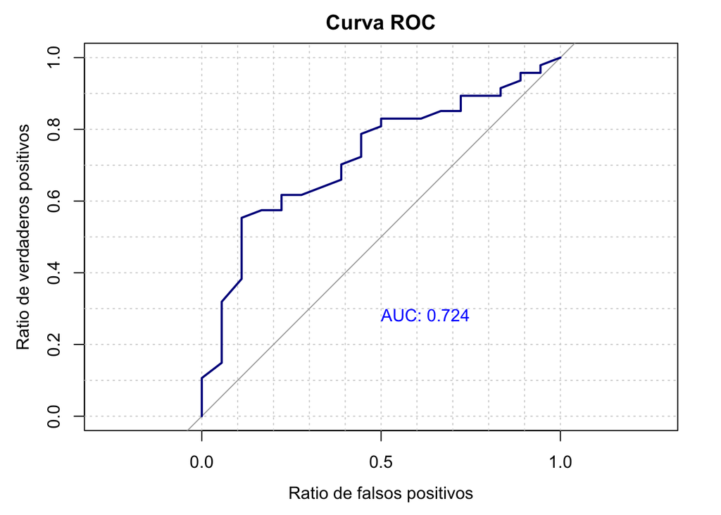

```r
plot(roc_obj, main = "Curva ROC", xlab = "Ratio de falsos positivos", ylab = "Ratio de verdaderos positivos",
     print.auc = TRUE, print.auc.y = 0.3, print.auc.col = "blue",
     legacy.axes = TRUE , grid = TRUE, grid.col = "lightgray",
     lwd = 2, col = "darkblue")
```

El área bajo la curva nos devuelve un valor de 0.724, por lo que podríamos considerlo como un modelo “regular”.